# Portafolio Ejecutivo: Análisis de Exportaciones

Evaluación estadística y de riesgos en mercados internacionales (BCCR)

## 1. Introducción y Carga de Datos

En este proyecto analizamos el comportamiento histórico de las exportaciones utilizando datos oficiales del Banco Central de Costa Rica (BCCR). El objetivo principal es identificar tendencias, estacionalidades y métricas clave de rendimiento en los mercados internacionales.

- **Fuente de datos:** `exportaciones_bccr.csv`
- **Herramientas:** Python (Pandas, Matplotlib) y Quarto.

## 2. Análisis de Concentración (Pareto 80/20)

El análisis de Pareto evalúa la concentración de los ingresos por exportaciones entre los diferentes socios comerciales, identificando cuáles mercados concentran el mayor volumen de negocio.

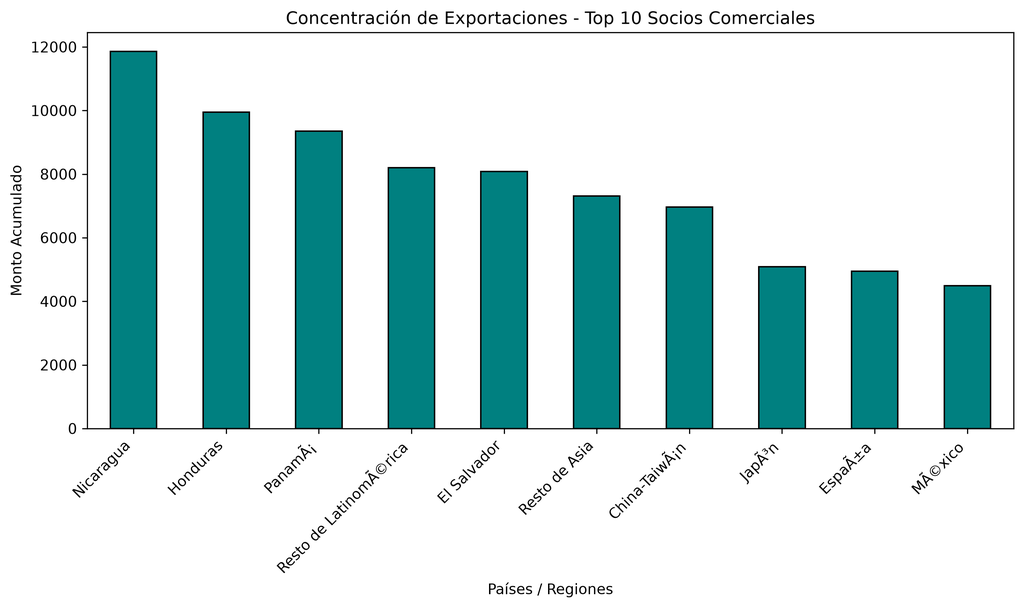

Análisis de Pareto

## 3. Coeficiente de Variación (Estabilidad vs. Volatilidad)

Se analiza la relación entre el volumen promedio de exportación y su desviación estándar para clasificar los mercados según su estabilidad o nivel de riesgo ante fluctuaciones mensuales.

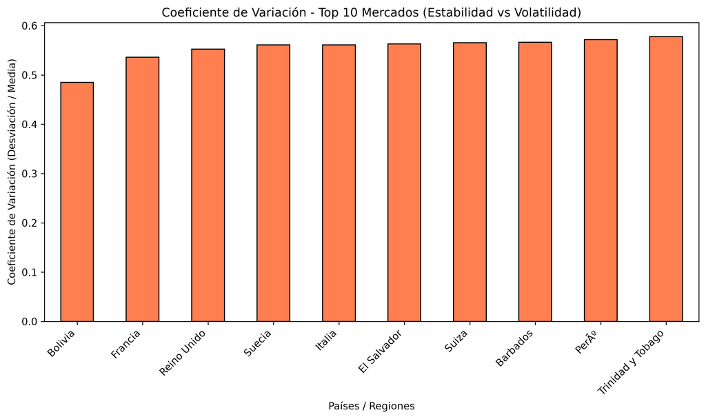

Coeficiente de Variación

## 4. Mapa de Estabilidad y Riesgo (Media vs. Volatilidad)

Este diagrama de dispersión cruza el volumen promedio de negocio con la volatilidad, permitiendo visualizar de manera ejecutiva el perfil de riesgo de cada mercado.

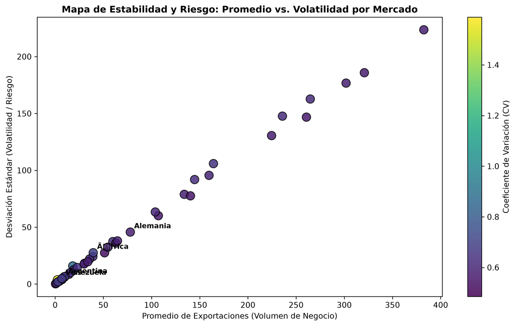

Mapa de Dispersión

## 5. Tasa de Crecimiento y Tendencia Temporal

Evaluación de la evolución histórica de los principales mercados con mayor expansión porcentual a lo largo del periodo analizado.

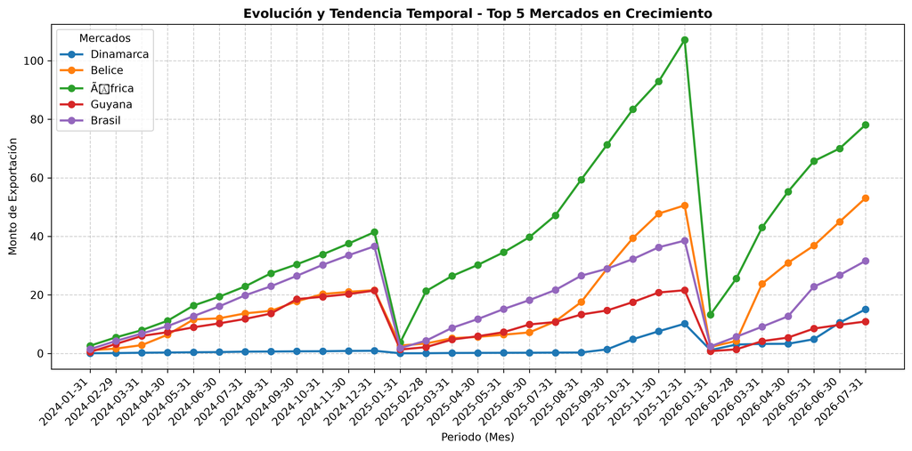

Tendencia Temporal

## 6. Matriz de Correlación Cruzada

El mapa de calor de correlaciones muestra el grado de sincronización entre los movimientos de los diferentes mercados internacionales.

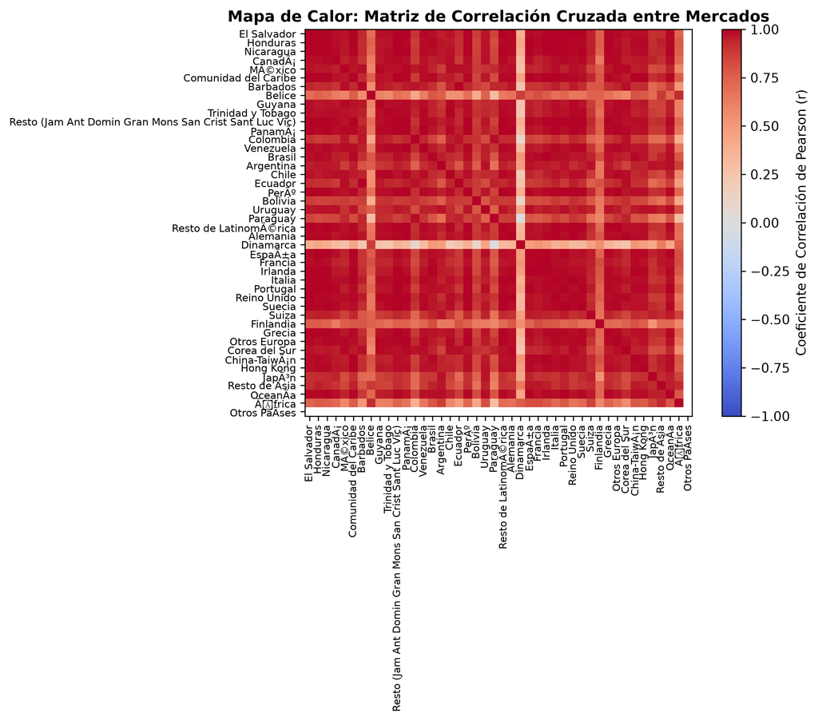

Matriz de Correlación

## 7. Conclusiones y Hallazgos Principales

- **Concentración Comercial:** Se observa una marcada dependencia en un grupo selecto de socios comerciales que acaparan el mayor porcentaje de las exportaciones totales.
- **Gestión de Riesgos:** La clasificación por coeficiente de variación permite distinguir mercados estables frente a aquellos altamente volátiles, facilitando la toma de decisiones estratégicas para la mitigación de riesgos.
- **Sincronización de Mercados:** El análisis de correlación cruzada identifica aquellos socios que responden de manera paralela ante choques externos y aquellos que ofrecen diversificación real.